# ADP7

```r
library(tidyverse)
library(data.table)
library(lubridate)
library(caret)
library(recipes)
library(rsample)
library(forecast)
library(gt) # rmarkdown table 관련, 시험이랑 관계 x
library(GGally)

theme_set(theme_bw())
```

18회 기출

# 1 고객 등급 예측 문제

- 시험 데이터 : ID, grade, days, count, amount
- grade가 0, 1, 2, 3, 4인 다중 분류 문제
- 시험 문제와 비슷한 데이터가 없어서 다른 데이터로 대체

## 1.1 Data descriptions

Zillow의 집값에 대한 데이터임. 각 행은 고유한 주택을 나타냄

- uid: A unique identifier
- city: 텍사스 주 오스틴 주변 마을
- description: Zillow list에 대한 설명
- latitude: Latitude
- longitude: Longitude
- garageSpaces: 차고의 수
- hasSpa: spa 공간의 유무
- yearBuilt: 건축년도
- numOfPatioAndPorchFeatures: patio or 베란다의 개수
- lotSizeSqFt: 거실 포함 부동산 부지 크기
- avgSchoolRating: 학교 유형에 따른 평균 학교 등급
- MedianStudentsPerTeacher: Zillow list에 있는 모든 학교의 교사당 학생 수 중앙값
- numOfBathrooms: 욕실의 수
- numOfBedrooms: 침실의 수
- priceRange: price ranges

```r
house <- fread("data/house.csv")
house %>% head() %>% gt()
```

| uid | city | description | homeType | latitude | longitude | garageSpaces | hasSpa | yearBuilt | numOfPatioAndPorchFeatures | lotSizeSqFt | avgSchoolRating | MedianStudentsPerTeacher | numOfBathrooms | numOfBedrooms | priceRange |
| --- | --- | --- | --- | --- | --- | --- | --- | --- | --- | --- | --- | --- | --- | --- | --- |
| 1748 | austin | MULTIPLE OFFERS submit best & final to Agent by Mon 21st - 5pm. Appt with Agent. RARE PANORAMIC VIEW LOT IN JESTER ESTATES SEE FOR MILES!! Home sits on Cul-de-sac & backs to a Preserve. Stunning remod… | Single Family | 30.38009 | -97.80062 | 0 | FALSE | 1988 | 0 | 102366 | 7.000000 | 17 | 4 | 4 | 650000+ |
| 13380 | austin | 4644 Hoffman Dr, Austin, TX 78749 is a single family home that contains 2,059 sq ft and was built in 1997. It contains 4 bedrooms and 3 bathrooms. | Single Family | 30.19949 | -97.85995 | 0 | FALSE | 1997 | 0 | 6534 | 6.666667 | 16 | 3 | 4 | 350000-450000 |
| 4115 | austin | 6804 Canal St, Austin, TX 78741 is a single family home that contains 832 sq ft and was built in 1952. It contains 2 bedrooms and 1 bathroom. | Single Family | 30.22740 | -97.69608 | 0 | FALSE | 1952 | 0 | 5619 | 3.333333 | 11 | 1 | 2 | 0-250000 |
| 6926 | austin | Beautiful large lot with established trees. Lovely, light filled, spacious home, with large dining area, living room and kitchen in open floor plan layout. Large family-friendly back yard, newly redon… | Single Family | 30.20547 | -97.79235 | 4 | FALSE | 1976 | 0 | 6416 | 4.000000 | 14 | 2 | 4 | 0-250000 |
| 14480 | austin | Stunning NW Hills designer remodel by Cedar and Oak Homes ~ Wonderful open & bright concept w/vaulted ceilings & formal dining room ~ Gorgeous kitchen features custom wood cabinetry, quartz countertop… | Single Family | 30.34511 | -97.76743 | 2 | FALSE | 1984 | 0 | 10759 | 7.000000 | 16 | 3 | 5 | 650000+ |
| 13448 | austin | 1808 Saint Albans Blvd, Austin, TX 78745 is a single family home that contains 1,554 sq ft and was built in 1964. It contains 3 bedrooms and 2 bathrooms. | Single Family | 30.21816 | -97.79425 | 0 | FALSE | 1964 | 0 | 9452 | 4.666667 | 14 | 2 | 3 | 450000-650000 |

## 1.2 EDA

```r
house %>% glimpse()
```

```
## Rows: 10,000
## Columns: 16
## $ uid                        <int> 1748, 13380, 4115, 6926, 14480, 13448, 1996~
## $ city                       <chr> "austin", "austin", "austin", "austin", "au~
## $ description                <chr> "MULTIPLE OFFERS submit best & final to Age~
## $ homeType                   <chr> "Single Family", "Single Family", "Single F~
## $ latitude                   <dbl> 30.38009, 30.19949, 30.22740, 30.20547, 30.~
## $ longitude                  <dbl> -97.80062, -97.85995, -97.69608, -97.79235,~
## $ garageSpaces               <int> 0, 0, 0, 4, 2, 0, 0, 1, 2, 0, 2, 1, 0, 1, 2~
## $ hasSpa                     <lgl> FALSE, FALSE, FALSE, FALSE, FALSE, FALSE, F~
## $ yearBuilt                  <int> 1988, 1997, 1952, 1976, 1984, 1964, 2015, 1~
## $ numOfPatioAndPorchFeatures <int> 0, 0, 0, 0, 0, 0, 0, 0, 0, 0, 0, 1, 0, 0, 0~
## $ lotSizeSqFt                <dbl> 102366.0, 6534.0, 5619.0, 6416.0, 10759.0, ~
## $ avgSchoolRating            <dbl> 7.000000, 6.666667, 3.333333, 4.000000, 7.0~
## $ MedianStudentsPerTeacher   <int> 17, 16, 11, 14, 16, 14, 16, 15, 14, 15, 14,~
## $ numOfBathrooms             <dbl> 4, 3, 1, 2, 3, 2, 4, 4, 3, 2, 3, 2, 3, 2, 2~
## $ numOfBedrooms              <int> 4, 4, 2, 4, 5, 3, 5, 6, 3, 4, 3, 4, 3, 2, 4~
## $ priceRange                 <chr> "650000+", "350000-450000", "0-250000", "0-~
```

```r
house <- house %>% janitor::clean_names()
house <- house %>%
  mutate_at(vars(city, home_type, has_spa, price_range), as.factor) %>%
  mutate_if(is.logical, as.factor)
```

```r
house %>%
  summary()
```

```
##       uid                      city      description
##  Min.   :    1   austin          :9898   Length:10000
##  1st Qu.: 3839   del valle       :  57   Class :character
##  Median : 7604   driftwood       :   8   Mode  :character
##  Mean   : 7627   dripping springs:   3
##  3rd Qu.:11436   manchaca        :   3
##  Max.   :15170   pflugerville    :  29
##                  west lake hills :   2
##               home_type       latitude       longitude      garage_spaces
##  Single Family     :9427   Min.   :30.09   Min.   :-98.02   Min.   : 0.00
##  Condo             : 333   1st Qu.:30.20   1st Qu.:-97.84   1st Qu.: 0.00
##  Townhouse         : 113   Median :30.28   Median :-97.77   Median : 1.00
##  Multiple Occupancy:  60   Mean   :30.29   Mean   :-97.78   Mean   : 1.23
##  Residential       :  27   3rd Qu.:30.37   3rd Qu.:-97.72   3rd Qu.: 2.00
##  Apartment         :  19   Max.   :30.52   Max.   :-97.57   Max.   :22.00
##  (Other)           :  21
##   has_spa       year_built   num_of_patio_and_porch_features lot_size_sq_ft
##  FALSE:9175   Min.   :1905   Min.   :0.0000                  Min.   :     100
##  TRUE : 825   1st Qu.:1975   1st Qu.:0.0000                  1st Qu.:    6534
##               Median :1993   Median :0.0000                  Median :    8189
##               Mean   :1989   Mean   :0.6672                  Mean   :   20710
##               3rd Qu.:2006   3rd Qu.:1.0000                  3rd Qu.:   10890
##               Max.   :2020   Max.   :8.0000                  Max.   :34154525
##
##  avg_school_rating median_students_per_teacher num_of_bathrooms
##  Min.   :2.333     Min.   :10.00               Min.   : 1.000
##  1st Qu.:4.000     1st Qu.:14.00               1st Qu.: 2.000
##  Median :5.667     Median :15.00               Median : 3.000
##  Mean   :5.766     Mean   :14.86               Mean   : 2.692
##  3rd Qu.:7.000     3rd Qu.:16.00               3rd Qu.: 3.000
##  Max.   :9.500     Max.   :19.00               Max.   :10.000
##
##  num_of_bedrooms         price_range
##  Min.   : 1.000   0-250000     :1249
##  1st Qu.: 3.000   250000-350000:2356
##  Median : 3.000   350000-450000:2301
##  Mean   : 3.449   450000-650000:2275
##  3rd Qu.: 4.000   650000+      :1819
##  Max.   :10.000
##
```

```r
house %>% select_if(is.numeric) %>% dim()
```

```
## [1] 10000    11
```

```r
house
```

[output not shown]

[output cut: 57 more lines]

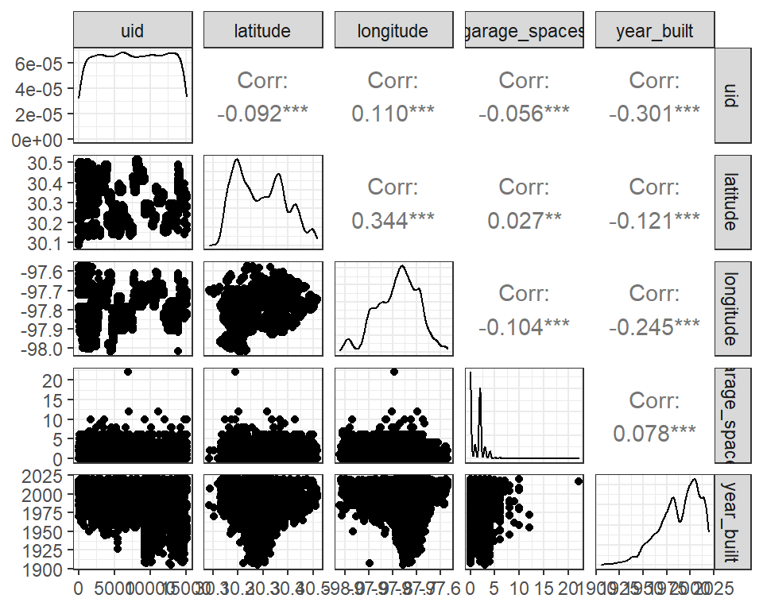

```r
house %>%
  select_if(is.numeric) %>%
  ggpairs(columns = 1:5)
```

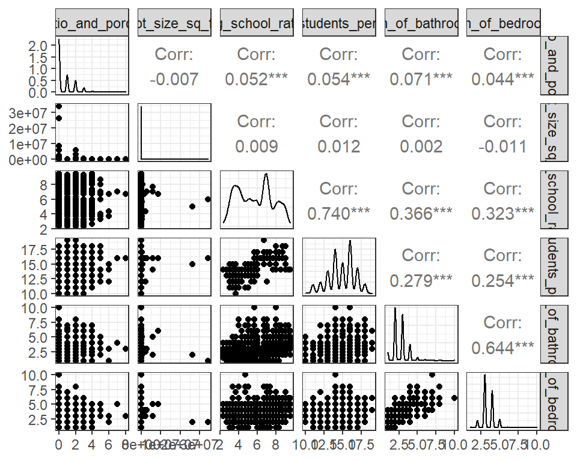

```r
house %>%
  select_if(is.numeric) %>%
  ggpairs(columns = 6:11)
```

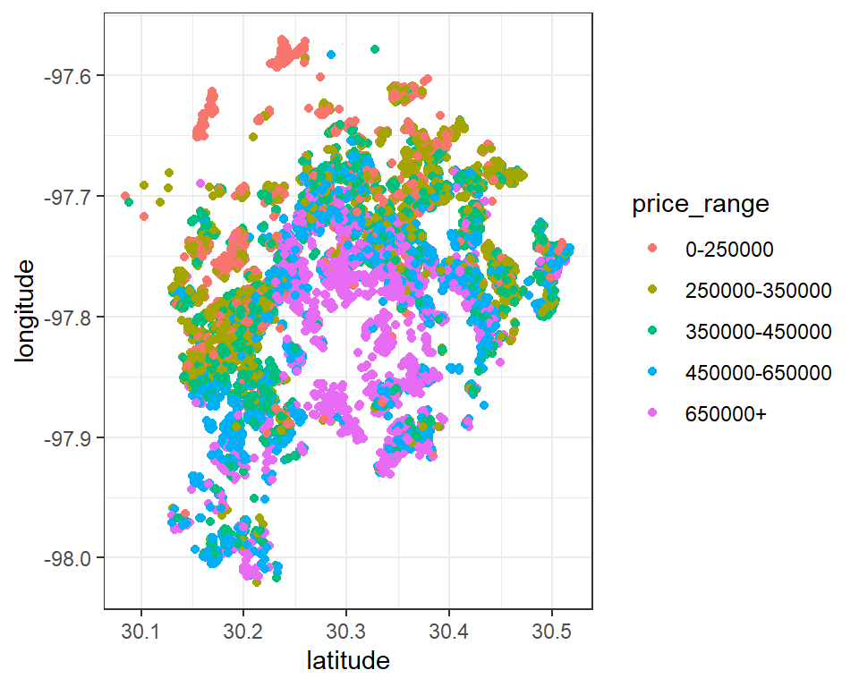

```r
house %>%
  ggplot(aes(x = latitude, y = longitude, color = price_range)) +
  geom_point()
```

[figure not shown]

```r
house %>%
  ggplot(aes(x = latitude, y = longitude, fill = price_range)) +
  geom_hex(bins = 50)
```

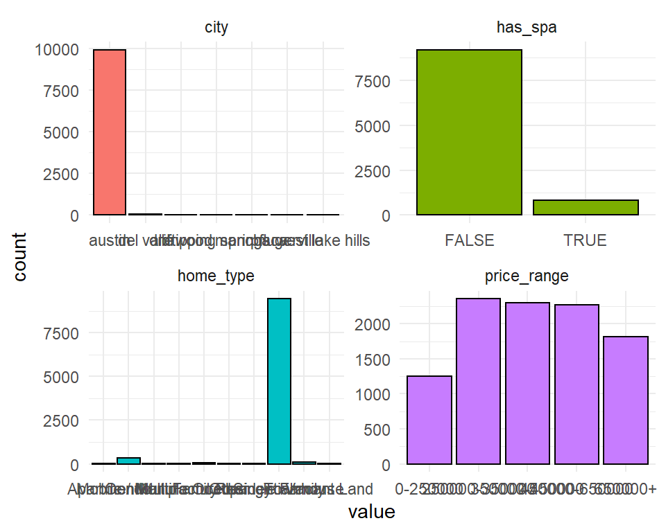

```r
house %>%
  keep(is.factor) %>%
  gather() %>%
  ggplot() +
  geom_bar(mapping = aes(x=value,fill=key), color="black") +
  facet_wrap(~ key, scales = "free") +
  theme_minimal() +
  theme(legend.position = 'none')
```

## 1.3 결측치 처리

- 실제 데이터에는 결측치가 있었음
- recipes 패키지 활용해서 처리
- recipes 사용법 생략
- description(텍스트) 변수는 실제 시험 데이터에서는 나오지 않았기 때문에 생략

```r
house %>% is.na() %>% colSums()
```

```
##                             uid                            city
##                               0                               0
##                     description                       home_type
##                               0                               0
##                        latitude                       longitude
##                               0                               0
##                   garage_spaces                         has_spa
##                               0                               0
##                      year_built num_of_patio_and_porch_features
##                               0                               0
##                  lot_size_sq_ft               avg_school_rating
##                               0                               0
##     median_students_per_teacher                num_of_bathrooms
##                               0                               0
##                 num_of_bedrooms                     price_range
##                               0                               0
```

## 1.4 파생변수 3개 생성 & 이유 작성

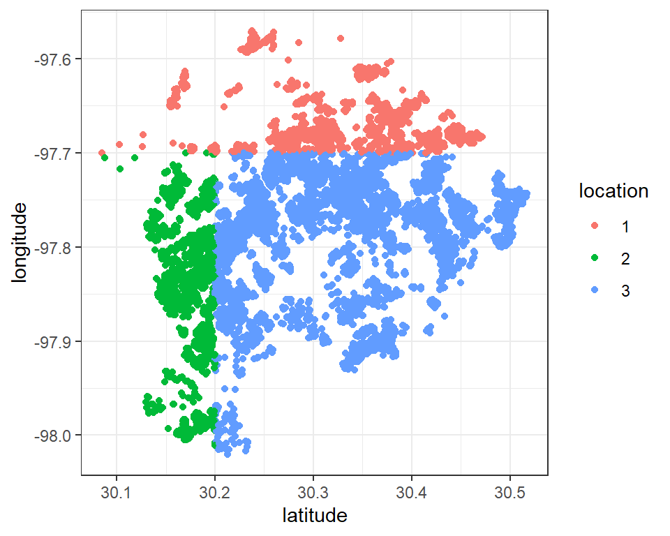

```r
house %>%
  recipe(price_range~.) %>%
  #step_meanimpute()
  step_rm(uid, description) %>%
  step_other(home_type, city, threshold = 0.8) %>%
  step_mutate(location = case_when(
    longitude >= -97.7 ~ 1,
    latitude<=30.2 & longitude<=-97.7 ~ 2,
    latitude>=30.2 & longitude<=-97.7 ~ 3,
  ),
  location = as.factor(location),
  price_range = as.factor(price_range)) %>%
  prep() %>%
  juice() %>%
  ggplot(aes(x = latitude, y = longitude, color = location)) +
  geom_point()
```

```r
house_rep <- house %>%
  recipe(price_range~.) %>%
  #step_meanimpute()
  step_rm(uid, description) %>%
  step_mutate(location = case_when(
    longitude >= -97.7 ~ 1,
    latitude<=30.2 & longitude<=-97.7 ~ 2,
    latitude>=30.2 & longitude<=-97.7 ~ 3,
  ),
  location = as.factor(location),
  price_range = as.factor(price_range)) %>%
  step_other(home_type, city, threshold = 0.8) %>%
  step_dummy(all_nominal(), -all_outcomes())
house_rec <- house_rep %>% prep() %>% juice()
```

```r
house %>% select_if(is.factor)
```

```
##          city     home_type has_spa   price_range
##     1: austin Single Family   FALSE       650000+
##     2: austin Single Family   FALSE 350000-450000
##     3: austin Single Family   FALSE      0-250000
##     4: austin Single Family   FALSE      0-250000
##     5: austin Single Family   FALSE       650000+
##    ---
##  9996: austin Single Family   FALSE       650000+
##  9997: austin Single Family   FALSE 250000-350000
##  9998: austin Single Family   FALSE 350000-450000
##  9999: austin Single Family   FALSE 250000-350000
## 10000: austin Single Family   FALSE      0-250000
```

```r
som_rec <- house %>%
  recipe(price_range~.) %>%
  step_rm(uid, description, city, home_type, has_spa) %>%
  step_mutate(price_range = as.factor(price_range))

som_data <- som_rec %>% prep() %>% juice()
```

## 1.5 Train/test 7:3 분할

```r
library(rsample)

idx <- initial_split(som_data, prop = 0.7, strata = price_range)

train <- training(idx)
test <- testing(idx)
```

## 1.6 SOM 군집분석

```r
x <- data.frame(col1 = c(1, 4, 4),
                col2 = c(2, 3, 1),
                col3 = c(1, 2, 3))

x <- scale(x)
x
```

```
##            col1 col2 col3
## [1,] -1.1547005    0   -1
## [2,]  0.5773503    1    0
## [3,]  0.5773503   -1    1
## attr(,"scaled:center")
## col1 col2 col3
##    3    2    2
## attr(,"scaled:scale")
##     col1     col2     col3
## 1.732051 1.000000 1.000000
```

```r
attr(x, "scaled:center")
```

```
## col1 col2 col3
##    3    2    2
```

```r
library(kohonen)
trainX <- scale(train[, -11])
testX <- scale(test[, -11], center = attr(trainX, "scaled:center"))

som_fit <- xyf(trainX, classvec2classmat(train$price_range),
    grid = somgrid(13, 13, "hexagonal"), rlen = 100)

som_pred <- predict(som_fit, newdata = testX, whatmap = 1)
```

## 1.7 confusion matrix

```r
library(caret)
caret::confusionMatrix(test$price_range, som_pred$predictions[[2]])
```

```
## Confusion Matrix and Statistics
##
##                Reference
## Prediction      0-250000 250000-350000 350000-450000 450000-650000 650000+
##   0-250000           132           166            52            16       9
##   250000-350000       71           394           164            63      15
##   350000-450000       19           192           270           181      29
##   450000-650000        7            78           137           351     110
##   650000+              4            24            28           148     342
##
## Overall Statistics
##
##                Accuracy : 0.496
##                  95% CI : (0.478, 0.5141)
##     No Information Rate : 0.2845
##     P-Value [Acc > NIR] : < 2.2e-16
##
##                   Kappa : 0.3582
##
##  Mcnemar's Test P-Value : 2.493e-12
##
## Statistics by Class:
##
##                      Class: 0-250000 Class: 250000-350000 Class: 350000-450000
## Sensitivity                  0.56652               0.4614              0.41475
## Specificity                  0.91224               0.8543              0.82093
## Pos Pred Value               0.35200               0.5573              0.39074
## Neg Pred Value               0.96155               0.7996              0.83514
## Prevalence                   0.07761               0.2845              0.21686
## Detection Rate               0.04397               0.1312              0.08994
## Detection Prevalence         0.12492               0.2355              0.23018
## Balanced Accuracy            0.73938               0.6578              0.61784
##                      Class: 450000-650000 Class: 650000+
## Sensitivity                        0.4625         0.6772
## Specificity                        0.8520         0.9183
## Pos Pred Value                     0.5139         0.6264
## Neg Pred Value                     0.8241         0.9336
## Prevalence                         0.2528         0.1682
## Detection Rate                     0.1169         0.1139
## Detection Prevalence               0.2275         0.1819
## Balanced Accuracy                  0.6572         0.7978
```

## 1.8 분류 분석 4가지

- rf, 다층 신경망 등 4가지 방법으로 예측 후 F1 score, ROC curve 생성

```r
library(rsample)
make.names(levels(house_rec$price_range))
```

```
## [1] "X0.250000"      "X250000.350000" "X350000.450000" "X450000.650000"
## [5] "X650000."
```

```r
house_rec$price_range <- factor(house_rec$price_range, labels = make.names(levels(house_rec$price_range)))


idx <- initial_split(house_rec, prop = 0.7, strata = price_range)

train <- training(idx)
test <- testing(idx)
```

```r
library(caret)

set.seed(123)
control <- trainControl(method='cv',
                        number=5,
                        classProbs = T, # target이 1 or 0이 아니라 yes or no 형태여야함.
                        summaryFunction = multiClassSummary, # auc, sensitivity, specificity
                        savePredictions = T
                        )
tunegrid <- expand.grid(mtry = c(1:2))

library(tictoc)
tic()
rf_gridsearch2 <- train(price_range ~ .,
                       data = train,
                       method = 'rf',
                       trControl = control,
                       tuneGrid = tunegrid,
                       metric = "logLoss")
toc()
```

```
## 58.08 sec elapsed
```

```r
rf_gridsearch2
```

```
## Random Forest
##
## 6998 samples
##   15 predictor
##    5 classes: 'X0.250000', 'X250000.350000', 'X350000.450000', 'X450000.650000', 'X650000.'
##
## No pre-processing
## Resampling: Cross-Validated (5 fold)
## Summary of sample sizes: 5597, 5597, 5599, 5600, 5599
## Resampling results across tuning parameters:
##
##   mtry  logLoss   AUC        prAUC      Accuracy   Kappa      Mean_F1
##   1     1.252965  0.8309024  0.5724264  0.5112896  0.3736183  0.4807395
##   2     1.009371  0.8701748  0.6454507  0.6055988  0.4980680  0.6077182
##   Mean_Sensitivity  Mean_Specificity  Mean_Pos_Pred_Value  Mean_Neg_Pred_Value
##   0.4905217         0.8737027         0.5973502            0.8803406
##   0.5985033         0.8986556         0.6334095            0.8997807
##   Mean_Precision  Mean_Recall  Mean_Detection_Rate  Mean_Balanced_Accuracy
##   0.5973502       0.4905217    0.1022579            0.6821122
##   0.6334095       0.5985033    0.1211198            0.7485794
##
## logLoss was used to select the optimal model using the smallest value.
## The final value used for the model was mtry = 2.
```

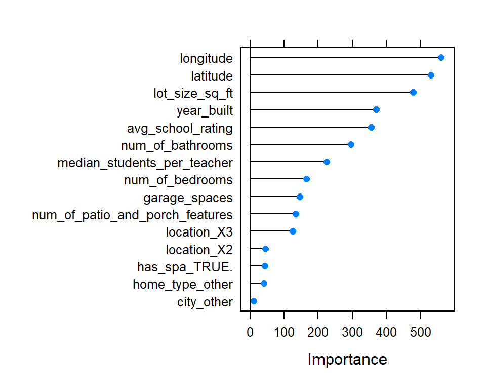

```r
plot(varImp(rf_gridsearch2, scale = F))
```

```r
pred_m <- predict(rf_gridsearch2, newdata = test, type = "raw")

cmatrix <- caret::confusionMatrix(pred_m, test$price_range)
cmatrix
```

```
## Confusion Matrix and Statistics
##
##                 Reference
## Prediction       X0.250000 X250000.350000 X350000.450000 X450000.650000
##   X0.250000            166             48              7              3
##   X250000.350000       151            489            195             36
##   X350000.450000        43            139            321            130
##   X450000.650000        13             23            160            427
##   X650000.               2              8              8             87
##                 Reference
## Prediction       X650000.
##   X0.250000             1
##   X250000.350000        4
##   X350000.450000        8
##   X450000.650000      108
##   X650000.            425
##
## Overall Statistics
##
##                Accuracy : 0.6089
##                  95% CI : (0.5912, 0.6264)
##     No Information Rate : 0.2355
##     P-Value [Acc > NIR] : < 2.2e-16
##
##                   Kappa : 0.502
##
##  Mcnemar's Test P-Value : < 2.2e-16
##
## Statistics by Class:
##
##                      Class: X0.250000 Class: X250000.350000
## Sensitivity                   0.44267                0.6917
## Specificity                   0.97754                0.8318
## Pos Pred Value                0.73778                0.5589
## Neg Pred Value                0.92474                0.8975
## Prevalence                    0.12492                0.2355
## Detection Rate                0.05530                0.1629
## Detection Prevalence          0.07495                0.2915
## Balanced Accuracy             0.71010                0.7617
##                      Class: X350000.450000 Class: X450000.650000
## Sensitivity                         0.4645                0.6252
## Specificity                         0.8615                0.8689
## Pos Pred Value                      0.5008                0.5841
## Neg Pred Value                      0.8433                0.8873
## Prevalence                          0.2302                0.2275
## Detection Rate                      0.1069                0.1422
## Detection Prevalence                0.2135                0.2435
## Balanced Accuracy                   0.6630                0.7470
##                      Class: X650000.
## Sensitivity                   0.7784
## Specificity                   0.9572
## Pos Pred Value                0.8019
## Neg Pred Value                0.9511
## Prevalence                    0.1819
## Detection Rate                0.1416
## Detection Prevalence          0.1765
## Balanced Accuracy             0.8678
```

```r
mlp_rep <- house %>%
  recipe(price_range~.) %>%
  #step_meanimpute()
  step_rm(uid, description) %>%
  step_mutate(location = case_when(
    longitude >= -97.7 ~ 1,
    latitude<=30.2 & longitude<=-97.7 ~ 2,
    latitude>=30.2 & longitude<=-97.7 ~ 3,
  ),
  location = as.factor(location),
  price_range = as.factor(price_range)) %>%
  step_other(home_type, city, threshold = 0.8) %>%
  step_dummy(all_nominal(), -all_outcomes(), one_hot = T) %>%
  step_normalize(all_numeric_predictors())
mlp_rec <- mlp_rep %>% prep() %>% juice()
```

```r
mlp_rec$price_range <- factor(mlp_rec$price_range, labels = make.names(levels(mlp_rec$price_range)))

mlp_rec$price_range %>% head()
```

```
## [1] X650000.       X350000.450000 X0.250000      X0.250000      X650000.
## [6] X450000.650000
## Levels: X0.250000 X250000.350000 X350000.450000 X450000.650000 X650000.
```

```r
idx <- initial_split(mlp_rec, prop = 0.7, strata = price_range)

train <- training(idx)
test <- testing(idx)

set.seed(123)
control <- trainControl(method='cv',
                        number=5,
                        classProbs = T, # target이 1 or 0이 아니라 yes or no 형태여야함.
                        summaryFunction = multiClassSummary, # auc, sensitivity, specificity
                        savePredictions = T
                        )
```

```r
# RSNNS 0.4-12
# nnet  7.3-14

library(tictoc)
tic()
mlp_gridsearch2 <- train(price_range ~ .,
                       data = train,
                       method = 'nnet',
                       trControl = control,
                       tuneLength = 10,
                       metric = "logLoss",
                       verbose = F)
toc()
mlp_gridsearch2


pred_m <- predict(mlp_gridsearch2, newdata = test, type = "raw")

cmatrix <- caret::confusionMatrix(pred_m, test$price_range)
cmatrix


library(tictoc)
tic()
mlp_gridsearch3 <- train(price_range ~ .,
                       data = train,
                       method = 'mlp',
                       trControl = control,
                       tuneLength = 10, # 20 정도 해야지 성능 나옴
                       metric = "logLoss",
                       verbose = F)
toc()
mlp_gridsearch3

pred_m <- predict(mlp_gridsearch3, newdata = test, type = "raw")

cmatrix <- caret::confusionMatrix(pred_m, test$price_range)
cmatrix
```

[output not shown]

```r
library(tictoc)
tic()
xgb_gridsearch <- train(price_range ~ .,
                       data = train,
                       method = 'xgbTree',
                       trControl = control,
                       tuneLength = 1,
                       metric = "logLoss")
toc()

pred_m <- predict(xgb_gridsearch, newdata = test, type = "raw")

cmatrix <- caret::confusionMatrix(pred_m, test$price_range)
cmatrix
```

**F1 score**

```r
cmatrix$byClass
```

[output not shown]

**ROC curve**

```r
library(pROC)
pred_prob <- predict(xgb_gridsearch, newdata = test, type = "prob")
actual <- as.numeric(factor(test$price_range))-1

roc_result <- multiclass.roc(actual, pred_prob$X650000.)
roc_result

pROC::auc(roc_result)


par(pty="s")

rs <- roc_result[['rocs']]
plot.roc(rs[[1]],
         print.thres = TRUE,
         print.auc = TRUE,
         legacy.axes = T)
sapply(2:length(rs),function(i) lines.roc(rs[[i]],col=i))
```

[output not shown]

# 2 텍스트 마이닝(영어)

## 2.1 text 파일로 주어질 경우

```r
bts <- readLines("data/bts.txt")
bts %>% head()
```

```
## [1] "My name is Kim Namjoon, also known as RM, the leader of the group BTS. It is an incredible honor to be invited to an occasion with such significance for today's young generation."
## [2] ""
## [3] "Last November, BTS launched the Love Myself campaign with UNICEF built on our belief that true love first begins with loving myself. We've been partnering with UNICEF's End Violence program to protect children and young people all over the world from violence. And our fans have become a majo…
## [4] ""
## [5] "I’d like to begin by talking about myself."
## [6] ""
```

**문장 토큰화**

- 텍스트 원자료를 분석할 수 있도록 토큰으로 나누는 단계

**unnest_tokens(df, output, input, to_lower = T)**

- output : word 고정
- input : tibble 형식의 text
- to_lower = T : 대문자를 소문자로 변경

```r
#devtools::install_version("tidytext", version = "0.2.6")
#devtools::install_version("stopwords", version = "2.1")
#devtools::install_version("tm", version = "0.7-8")
library(tidytext)
```

```r
library(tidytext)

tibble(text = bts) %>%
  unnest_tokens(output = word,
                input = text,
                to_lower = T # 대문자를 소문자로 변경
                ) %>%
  head()
```

```
## # A tibble: 6 x 1
##   word
##   <chr>
## 1 my
## 2 name
## 3 is
## 4 kim
## 5 namjoon
## 6 also
```

**불용어 처리**

- 불용어는 말그대로 사용하지 않는 단어로 해석에 필요가 없으므로 제거해주어야함
- 불용어를 처리하는 방법은 두가지가 있음
  - 불용어 사전에 단어 추가
  - 불용어 직접 처리

**불용어사전 이용하는 방법**

- 가장 간단한 방법은 get_stopwords()를 anti_join하면 됨
- get_stopwords()는 불용어가 적으므로 tidytext에 내장된 stop_words 데이터를 이용하는 것이 좋음
- stop_words는 SMART, snowball, onix 불용어집 3개를 모아놓은 데이터임

**anti_join**

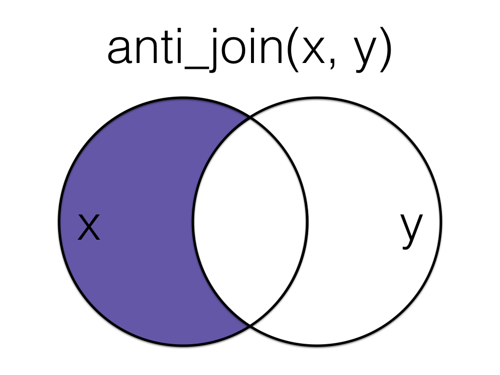

```r
get_stopwords() %>% head()
```

```
## # A tibble: 6 x 2
##   word   lexicon
##   <chr>  <chr>
## 1 i      snowball
## 2 me     snowball
## 3 my     snowball
## 4 myself snowball
## 5 we     snowball
## 6 our    snowball
```

```r
get_stopwords() %>% dim()
```

```
## [1] 175   2
```

```r
tibble(text = bts) %>%
  unnest_tokens(output = word,
                input = text,
                to_lower = T # 대문자를 소문자로 변경
                ) %>%
  anti_join(get_stopwords()) %>%
  head()
```

```
## # A tibble: 6 x 1
##   word
##   <chr>
## 1 name
## 2 kim
## 3 namjoon
## 4 also
## 5 known
## 6 rm
```

```r
#data("stop_words")
stop_words %>% head()
```

```
## # A tibble: 6 x 2
##   word      lexicon
##   <chr>     <chr>
## 1 a         SMART
## 2 a's       SMART
## 3 able      SMART
## 4 about     SMART
## 5 above     SMART
## 6 according SMART
```

```r
tibble(text = bts) %>%
  unnest_tokens(output = word,
                input = text,
                to_lower = T # 대문자를 소문자로 변경
                ) %>%
  anti_join(stop_words) %>%
  head()
```

```
## # A tibble: 6 x 1
##   word
##   <chr>
## 1 kim
## 2 namjoon
## 3 rm
## 4 leader
## 5 bts
## 6 incredible
```

**불용어 직접 처리**

```r
bts_v <- bts %>%
  str_replace_all("i’d", "i")

tibble(text = bts_v) %>%
    unnest_tokens(output = word,
                input = text,
                to_lower = T # 대문자를 소문자로 변경
                ) %>%
  anti_join(stop_words) %>%
  head(n = 25)
```

```
## # A tibble: 25 x 1
##    word
##    <chr>
##  1 kim
##  2 namjoon
##  3 rm
##  4 leader
##  5 bts
##  6 incredible
##  7 honor
##  8 invited
##  9 occasion
## 10 significance
## # ... with 15 more rows
```

**불용어 사전 수정**

- add_rows()로 불용어 추가 가능
- tibble로 만들고 직접 추가도 가능

```r
stop_words %>% add_row(word = "syou’re", # 추가할 단어
                       lexicon = "NEW",  # 단어 사전 명칭
                       .before = 1) # 첫 행에 추가
```

```
## # A tibble: 1,150 x 2
##    word        lexicon
##    <chr>       <chr>
##  1 syou’re     NEW
##  2 a           SMART
##  3 a's         SMART
##  4 able        SMART
##  5 about       SMART
##  6 above       SMART
##  7 according   SMART
##  8 accordingly SMART
##  9 across      SMART
## 10 actually    SMART
## # ... with 1,140 more rows
```

```r
stop_add <- tibble(word = c("i’d", "i’m"),
                   lexicon = "added")

stop_words2 <- bind_rows(stop_words, stop_add)
stop_words2 %>% tail()
```

```
## # A tibble: 6 x 2
##   word     lexicon
##   <chr>    <chr>
## 1 younger  onix
## 2 youngest onix
## 3 your     onix
## 4 yours    onix
## 5 i’d      added
## 6 i’m      added
```

```r
tibble(text = bts_v) %>%
    unnest_tokens(output = word,
                input = text,
                to_lower = T # 대문자를 소문자로 변경
                ) %>%
  anti_join(stop_words2) %>%
  head(n = 25)
```

```
## # A tibble: 25 x 1
##    word
##    <chr>
##  1 kim
##  2 namjoon
##  3 rm
##  4 leader
##  5 bts
##  6 incredible
##  7 honor
##  8 invited
##  9 occasion
## 10 significance
## # ... with 15 more rows
```

**빈도 그래프**

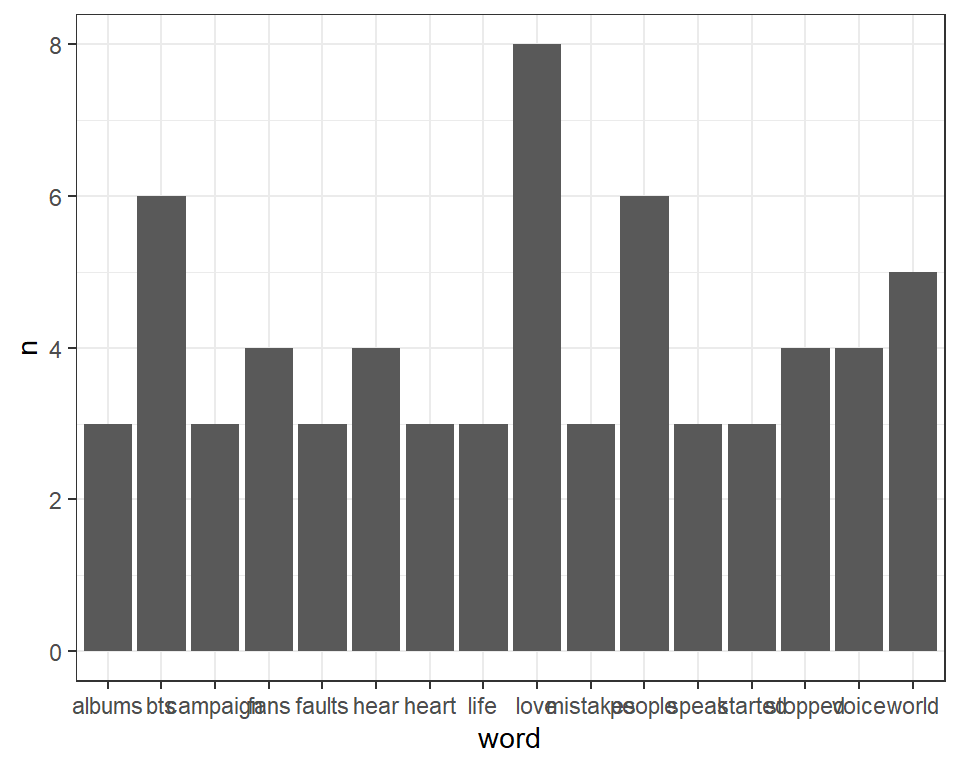

```r
tibble(text = bts_v) %>%
    unnest_tokens(output = word,
                input = text,
                to_lower = T # 대문자를 소문자로 변경
                ) %>%
  anti_join(stop_words2) %>%
  count(word, sort = TRUE) %>%
  slice_max(n, n = 10) %>%
  ggplot(aes(x = word, y = n)) + geom_bar(stat = "identity")
```

## 2.2 데이터 프레임에 text가 포함되어 있을 경우

```r
train_raw <- fread("data/house.csv")
train_raw %>% head()
```

[output not shown]

[output cut: 20 more lines]

**명사 추출**

```r
train_raw %>%
  mutate(priceRange = parse_number(priceRange) + 100000) %>%
  unnest_tokens(word, description)
```

```
##          uid   city      homeType latitude longitude garageSpaces hasSpa
##      1: 1748 austin Single Family 30.38009 -97.80062            0  FALSE
##      2: 1748 austin Single Family 30.38009 -97.80062            0  FALSE
##      3: 1748 austin Single Family 30.38009 -97.80062            0  FALSE
##      4: 1748 austin Single Family 30.38009 -97.80062            0  FALSE
##      5: 1748 austin Single Family 30.38009 -97.80062            0  FALSE
##     ---
## 715397: 4425 austin Single Family 30.34661 -97.61498            1  FALSE
## 715398: 4425 austin Single Family 30.34661 -97.61498            1  FALSE
## 715399: 4425 austin Single Family 30.34661 -97.61498            1  FALSE
## 715400: 4425 austin Single Family 30.34661 -97.61498            1  FALSE
## 715401: 4425 austin Single Family 30.34661 -97.61498            1  FALSE
##         yearBuilt numOfPatioAndPorchFeatures lotSizeSqFt avgSchoolRating
##      1:      1988                          0      102366               7
##      2:      1988                          0      102366               7
```

[output cut: 33 more lines]

**불용어 처리**

```r
train_raw %>%
  mutate(priceRange = parse_number(priceRange) + 100000) %>%
  unnest_tokens(word, description) %>%
  anti_join(get_stopwords()) # 불용어 사전으로 조인
```

```
##          uid   city      homeType latitude longitude garageSpaces hasSpa
##      1: 1748 austin Single Family 30.38009 -97.80062            0  FALSE
##      2: 1748 austin Single Family 30.38009 -97.80062            0  FALSE
##      3: 1748 austin Single Family 30.38009 -97.80062            0  FALSE
##      4: 1748 austin Single Family 30.38009 -97.80062            0  FALSE
##      5: 1748 austin Single Family 30.38009 -97.80062            0  FALSE
##     ---
## 525959: 4425 austin Single Family 30.34661 -97.61498            1  FALSE
## 525960: 4425 austin Single Family 30.34661 -97.61498            1  FALSE
## 525961: 4425 austin Single Family 30.34661 -97.61498            1  FALSE
## 525962: 4425 austin Single Family 30.34661 -97.61498            1  FALSE
## 525963: 4425 austin Single Family 30.34661 -97.61498            1  FALSE
##         yearBuilt numOfPatioAndPorchFeatures lotSizeSqFt avgSchoolRating
##      1:      1988                          0      102366               7
##      2:      1988                          0      102366               7
```

[output cut: 33 more lines]

**빈도 계산**

- 숫자가 포함되어 있음
- 제거 필요

```r
train_raw %>%
  mutate(priceRange = parse_number(priceRange) + 100000) %>%
  unnest_tokens(word, description) %>%
  anti_join(get_stopwords()) %>%  # 불용어 사전으로 조인
  count(word, sort = TRUE)
```

```
##           word     n
##     1:    home 11631
##     2: kitchen  5721
##     3:    room  5494
##     4:  austin  4941
##     5:     new  4772
##    ---
## 17891:      쐃     1
## 17892:      짼     1
## 17893:      쫊     1
## 17894:    창흹     1
## 17895:    횄짹     1
```

```r
train_raw %>%
  mutate(priceRange = parse_number(priceRange) + 100000) %>%
  unnest_tokens(word, description) %>%
  anti_join(get_stopwords()) %>%  # 불용어 사전으로 조인
  count(word, sort = TRUE) %>%
  filter(!word %in% as.character(1:5))
```

```
##           word     n
##     1:    home 11631
##     2: kitchen  5721
##     3:    room  5494
##     4:  austin  4941
##     5:     new  4772
##    ---
## 17886:      쐃     1
## 17887:      짼     1
## 17888:      쫊     1
## 17889:    창흹     1
## 17890:    횄짹     1
```

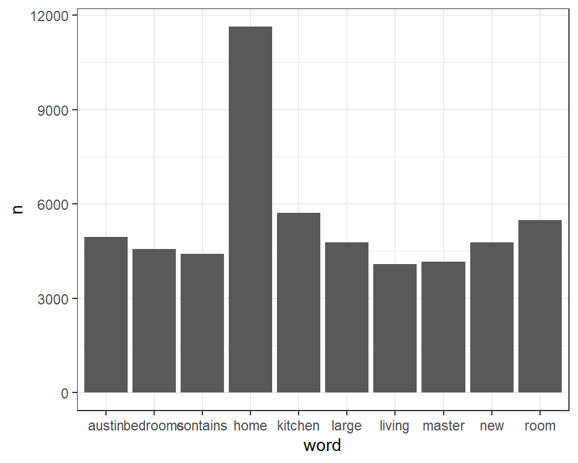

```r
train_raw %>%
  mutate(priceRange = parse_number(priceRange) + 100000) %>%
  unnest_tokens(word, description) %>%
  anti_join(get_stopwords()) %>%  # 불용어 사전으로 조인
  count(word, sort = TRUE) %>%
  filter(!word %in% as.character(1:5)) %>%
  slice_max(n, n = 10) %>%
  ggplot(aes(x = word, y = n)) + geom_bar(stat = "identity")
```

# 3 시계열분석

데이터 : 월별 교통사고건수

**ts()**

- frequency 값 지정 주의

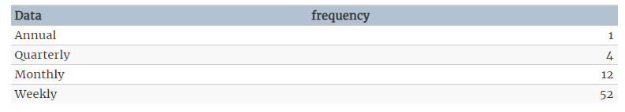

- 나머지 생략

## 3.1 정상성 확인

## 3.2 ARIMA 모델 3가지 제시

## 3.3 최적 모델 선택, 이유 설멍

## 3.4 최종 예측, 실제 결과와 비교, 평가방법을 선택한 이유 제시